# Project 1

Mingyu Yang

9/12/2018

# An Analysis on Finding Happiness As Single Parents? How Do Experiences that Make Them Happy Compare to These for Married Parents and Non-parents?

[figure not shown]

According to data published by the United States’ Census Bureau, around 30% of children in the United States are raised by single parents. There are many debates on whether single parents are as “good” as married ones. Those debates surround on topics including financial stability, psychological effect on children, social mobility and etc. These topics typically focus on the state of children instead of the parent herself/himself. An interesting question come in mind is what are the things that make single parents happy? Are they any different than those for married ones? How about comparing them to non-parents?

For our study, we will use the dataset HappyDB. It is a corpus of 100,000 happy moments gathered by the Amazon Mechanical Turk in 2017. We will compare data provided by single parent and married parent respectively. We will then study data provided by single and married non-parents and see if there exists similar trend as people with children.

The current R version I’m using and the necessary packages used are listed below. The original data are imported and we did some cleaning of the data. We removed punctuations, extra whitespace, empty words and numbers and converted upper case to lower case. We reduced words to their stems and removed meaningless stop words. We further combined the demographic data with the original data set. We then imported the demographic data to our cleaned data. We will use this cleaned and combined data for our analysis below.

The four democraphics groups we will study are single parents, married parents, single-non-parents and married non-parents.

```r
library(tidyverse)
library(tidytext)
library(DT)
library(scales)
library(wordcloud2)
library(gridExtra)
library(ngram)
library(tm)
library(wordcloud)
library(topicmodels)
library(ggplot2)
library(dplyr)
library(gplots)
library(reshape2)
library(stringr)

R.Version()$version.string
```

```
## [1] "R version 3.5.1 (2018-07-02)"
```

# General Analysis

## Length of Sentences

The length of sentences are stored in the count column of our cleaned dataset and we visualized this through a scatterplot, where each color represents a demographic group.

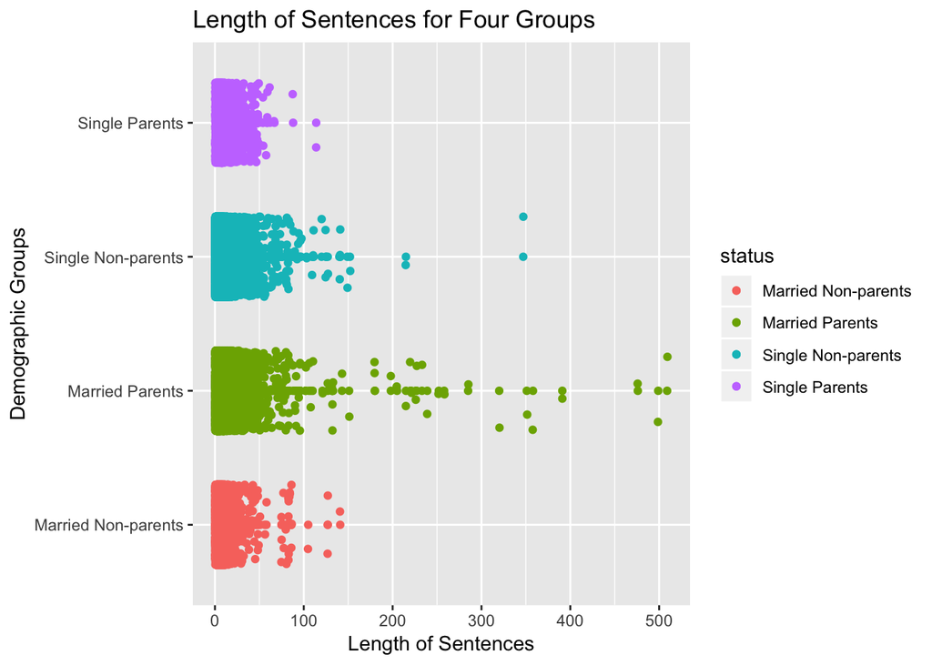

```r
ggplot(alldata, aes(count, status, color = status)) +
  geom_point() +
  geom_jitter(width = 0.5, height = 0.3) +
  ggtitle("Length of Sentences for Four Groups") +
  labs(x = "Length of Sentences", y = "Demographic Groups")
```

From the plot, we observe that married parents wrote more words in descripting their experiences. These may be because we have more data on married parents comparing to the other three groups.

## Word Frequency with Wordcloud.

We are going to examine the frequencies of words for each group and generate a word cloud for each demographic group.

## Wordcloud for Single Parents.

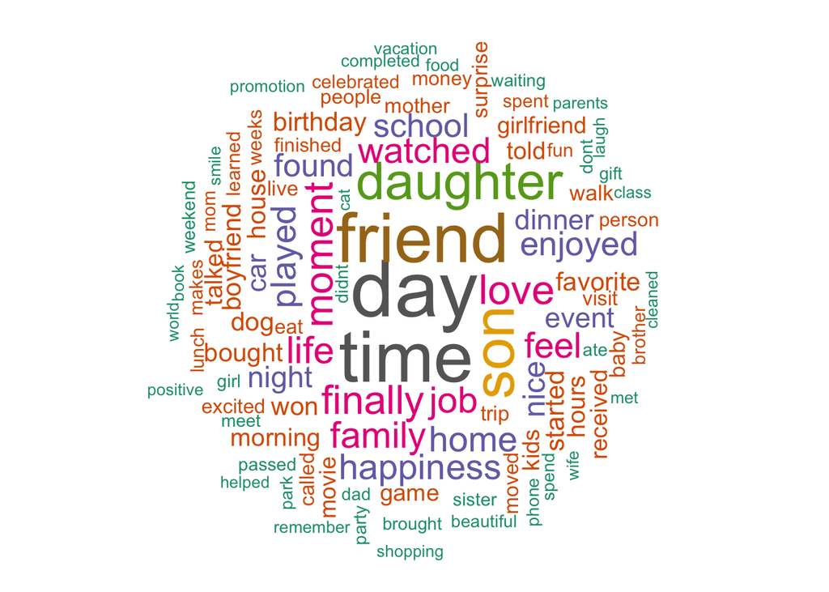

```r
#wordcloud for single parents.
docs.sp <- Corpus(VectorSource(hm_data.sp$text))
dtm.sp <- TermDocumentMatrix(docs.sp)
m.sp <- as.matrix(dtm.sp)
v.sp <- sort(rowSums(m.sp),decreasing=TRUE)
d.sp <- data.frame(word = names(v.sp),freq=v.sp)

set.seed(123)
wordcloud(words = d.sp$word, freq = d.sp$freq, min.freq = 1,
          max.words=100, random.order=FALSE, rot.per=0.35,
          colors=brewer.pal(8, "Dark2"))
```

## Wordcloud for Married Parents

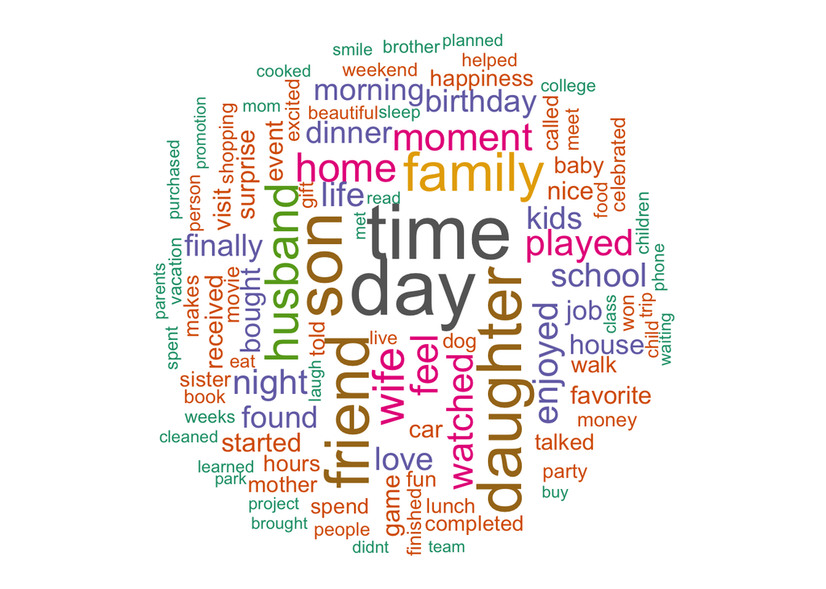

```r
#wordcloud for married parents
docs.mp <- Corpus(VectorSource(hm_data.mp$text))
dtm.mp <- TermDocumentMatrix(docs.mp)
m.mp <- as.matrix(dtm.mp)
v.mp <- sort(rowSums(m.mp),decreasing=TRUE)
d.mp <- data.frame(word = names(v.mp),freq=v.mp)

set.seed(123)
wordcloud(words = d.mp$word, freq = d.mp$freq, min.freq = 1,
          max.words=100, random.order=FALSE, rot.per=0.35,
          colors=brewer.pal(8, "Dark2"))
```

The top three most frequent appearance words are “day”, “time” and “friends” for single-parents and are “day”, “time” and “son” for married parents. The word “friend” drops to the fifth place for married parents. This indicates friends may be a more important aspect of life for single parent.

## Wordcould for Single Non-parents.

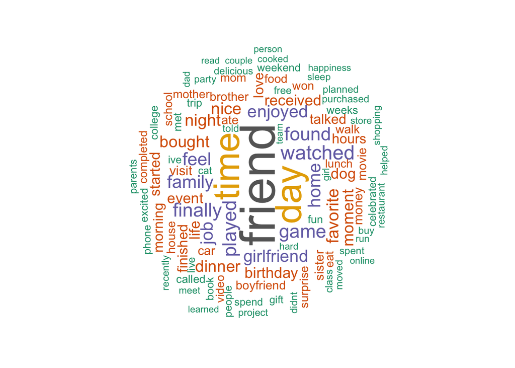

```r
#wordcould for single non-parents.
docs.s <- Corpus(VectorSource(hm_data.s$text))
dtm.s <- TermDocumentMatrix(docs.s)
m.s <- as.matrix(dtm.s)
v.s <- sort(rowSums(m.s),decreasing=TRUE)
d.s <- data.frame(word = names(v.s),freq=v.s)

set.seed(123)
wordcloud(words = d.s$word, freq = d.s$freq, min.freq = 1,
          max.words=100, random.order=FALSE, rot.per=0.35,
          colors=brewer.pal(8, "Dark2"))
```

## Wordcloud for Married Non-parents.

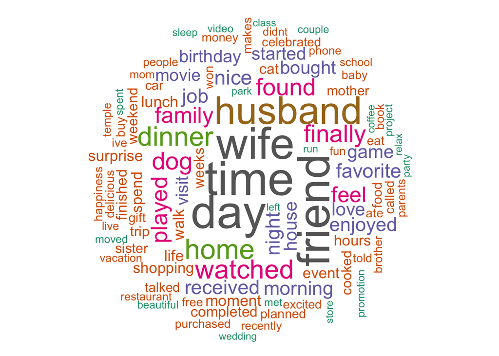

```r
#wordcould for married non-parents.
docs.m <- Corpus(VectorSource(hm_data.m$text))
dtm.m <- TermDocumentMatrix(docs.m)
m.m <- as.matrix(dtm.m)
v.m <- sort(rowSums(m.m),decreasing=TRUE)
d.m <- data.frame(word = names(v.m),freq=v.m)

set.seed(123)
wordcloud(words = d.m$word, freq = d.m$freq, min.freq = 1,
          max.words=100, random.order=FALSE, rot.per=0.35,
          colors=brewer.pal(8, "Dark2"))
```

# Sentiment Analysis

We will measure the sentiments of these happy moments. Although they should all exhibit positive and joyful sentiment indicating by the study, the intensities of the sentiments may vary between groups.

The “tidytext” package provides use several different lexicons that are dictionary of words with an sentiment assignment. Bing lexicon assigns words to positive and negative categories. The AFINN lexicon assign each word with a score from -5 to 5 where higher score means more positive sentiment. We examine will examine the results using both lexicons.

Let first use the Bing lexicons.

```r
bing <- function(df){
  tokens <- data_frame(df$text) %>% unnest_tokens(word, df$text)

  sentiment <- tokens %>%
  inner_join(get_sentiments("bing")) %>% # pull out the sentiment words
  count(sentiment) %>%   # count the number of positive and negative words
  spread(sentiment, n, fill = 0) %>%
  mutate(sentiment = positive/negative) # number of pos. words - number of neg. words

  return(sentiment)
}

bing.sp <- bing(hm_data.sp)$sentiment
bing.mp <- bing(hm_data.mp)$sentiment
bing.s <- bing(hm_data.s)$sentiment
bing.m <- bing(hm_data.m)$sentiment
bing.vec <- data.frame(bing = c(bing.sp, bing.mp,bing.s,bing.m))
```

```r
afinn <- function(df){
tokens <- data_frame(df$text) %>% unnest_tokens(word, df$text)

sentiment <- tokens %>%
  inner_join(get_sentiments("afinn"))   # pull out the sentiment words and asign score

  return(sentiment)
}

afinn.sp <- mean(afinn(hm_data.sp)$score)
afinn.mp <-mean(afinn(hm_data.mp)$score)
afinn.s <-mean(afinn(hm_data.s)$score)
afinn.m <-mean(afinn(hm_data.m)$score)

afinn.vec <- data.frame(afinn = c(afinn.sp, afinn.mp,afinn.s,afinn.m))
```

```r
demo.vec <- c("Single Parents", "Married Parents", "Single Non-parents", "Married Non-parent")
both <- cbind(demo.vec,  bing.vec, afinn.vec)
colnames(both) <- c('Demographic_Groups', 'bing', 'afinn')
both
```

```
##   Demographic_Groups     bing    afinn
## 1     Single Parents 2.712033 1.424318
## 2    Married Parents 2.722047 1.370004
## 3 Single Non-parents 2.539738 1.342369
## 4 Married Non-parent 2.643900 1.409176
```

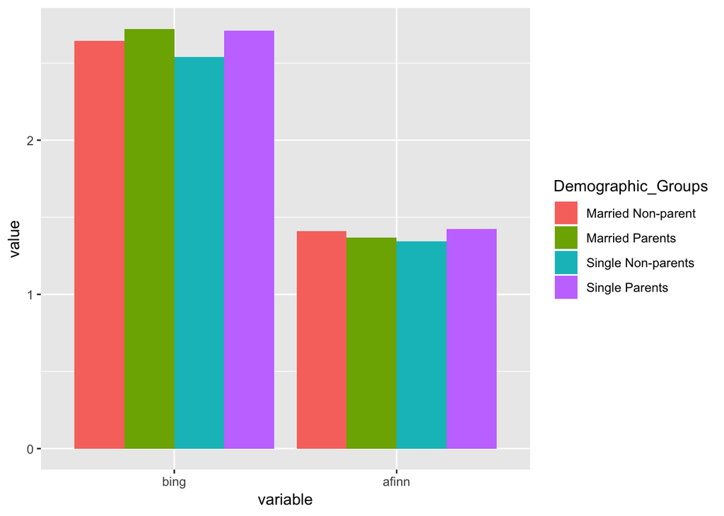

```r
melt.sentiments <- melt(both, id.vars = "Demographic_Groups")
ggplot(melt.sentiments, aes(variable, value)) +
  geom_bar(aes(fill = Demographic_Groups), position = "dodge", stat = "identity")
```

The sentiment score for bing is calculated by taking the amount of positive words divided by negative words. The result shows that married parents have a slightly higher score than single parents. Parents generally shows more positive sentiments than non-parents.

The sentiment score with afinn is calculated by taking the mean of scores in each group. Interestingly, The results shows that single parents have the highest score and single non-parents have the lowest score. Comparing the two methods, there aren’t a significant different between all demographic groups. We observe that single parents have relatively high scores comparing to others for both methods.

# Topic Modeling

We will extract topics with fitting a LDA model. We tried setting the numbers of topics as three to six. It turns out that setting three topics number make the most sense. The beta matrix tells us the probabilities of each word being generated from each topic.

We see that the word “accepted”" is generated from the topic 1 with a probability of 3.040925e-03. We visualized the top ten most frequent words in each topics. According to those words, we manually tag each topic as “Job”, “Family”,and “Friend”.

```r
order.data.cp <- hm_data.cp[order(hm_data.cp$wid),]
order.data.cp$status <- ifelse(order.data.cp$marital == "single", 1, 2)
order.data.c <- hm_data.c[order(hm_data.c$wid),]
order.data.c$status <- ifelse(order.data.c$marital == "single", 3, 4)

combine <- rbind(order.data.cp,order.data.c)

combine.data <- combine  %>%
                group_by(wid) %>%
                summarise(text = paste(text, collapse = " "), status = mean(status))

combine.docs <- Corpus(VectorSource(combine.data$text))
dtm.combine <- DocumentTermMatrix(combine.docs)

lda <- LDA(dtm.combine, k = 3, method = "GIBBS", control = list(seed = 2))
```

```r
# the beta matrix
topics <- tidy(lda, matrix = "beta")
head(topics,6)
```

```
## # A tibble: 6 x 3
##   topic term            beta
##   <int> <chr>          <dbl>
## 1     1 accepted 0.00304
## 2     2 accepted 0.000000508
## 3     3 accepted 0.000000495
## 4     1 afford   0.000763
## 5     2 afford   0.00000559
## 6     3 afford   0.000000495
```

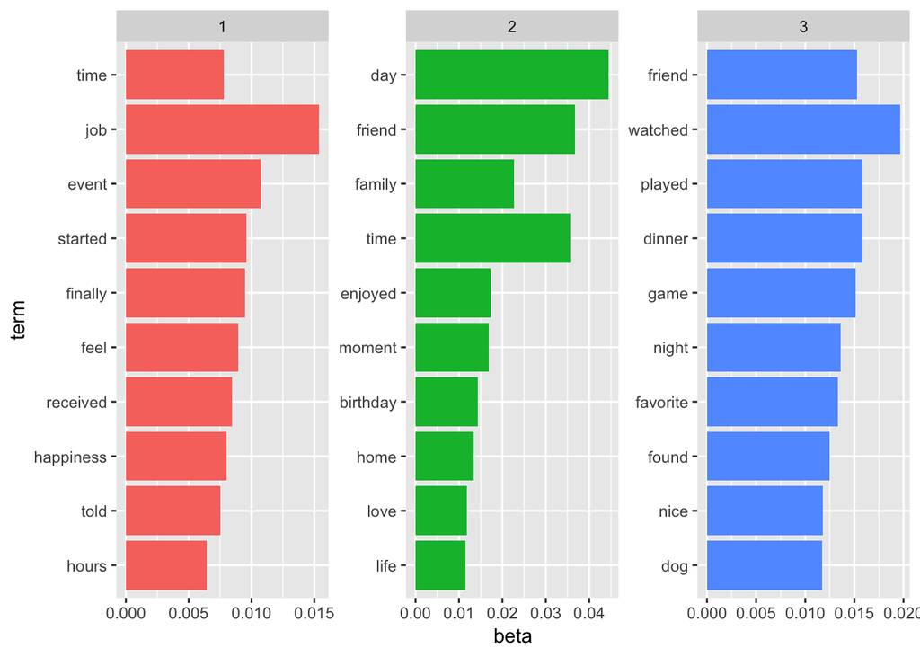

```r
#Find the top ten words in each topic.
top.words <- topics %>%
  group_by(topic) %>%
  top_n(10, beta) %>%
  ungroup() %>%
  arrange(topic, -beta)

top.words %>%
  mutate(term = reorder(term, beta)) %>%
  ggplot(aes(term, beta, fill = factor(topic))) +
  geom_col(show.legend = FALSE) +
  facet_wrap(~ topic, scales = "free") +
  coord_flip()
```

```r
topic.prob <- as.data.frame(lda@gamma)
topics.tag <- c( "Job", "Family","Friend")
lda.topics <- as.matrix(topics(lda))
combine.data$topic <- as.vector(lda.topics)
combine.data$ldatag <- topics.tag[lda.topics]
colnames(topic.prob) <- topics.tag

combine.data.corpus <- cbind(combine.data,topic.prob)
```

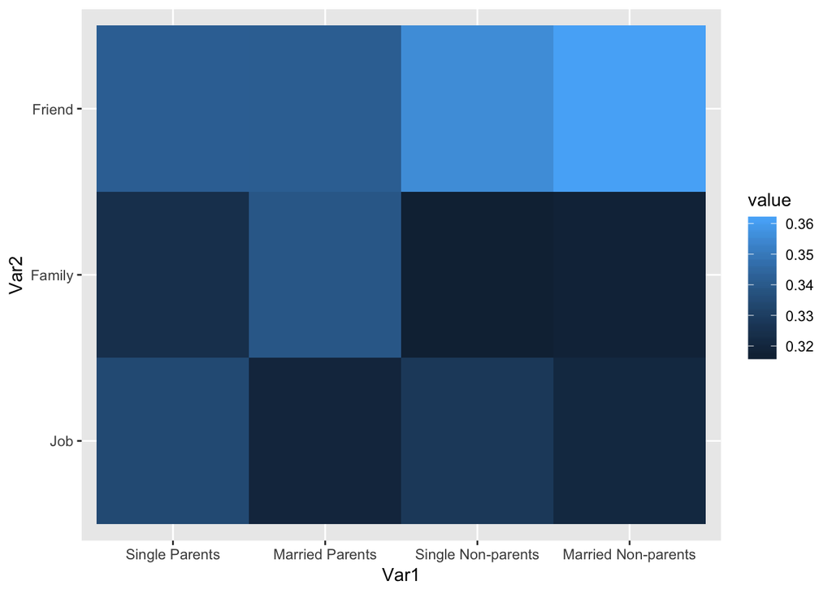

```r
topic.status<-tbl_df(combine.data.corpus)%>%
              select(status, Job:Friend)%>%
              group_by(status)%>%
              summarise_all(funs(mean))
topic.status=as.data.frame(topic.status)

rownames(topic.status)<-topic.status$status


as.mat <- as.matrix(topic.status[,-1])
rownames(as.mat) <- c('Single Parents','Married Parents','Single Non-parents','Married Non-parents')
melted_topic <- melt(as.mat)
ggplot(data = melted_topic, aes(x=Var1, y=Var2, fill=value)) +
  geom_tile()
```

# Conclusion

There aren’t significant differences comparing single parents to other demographic groups. We did observe that with this set of samples, married parent seems to use longer sentences in describing their happy moments.

By looking at the frequency of word，friend is an important aspect for single parents than married parents. Family related words appear less frequent for people who are married but don’t have children.

One interesting finding is that single parent shows relatively more positive sentiments than other groups.

# Sources:

http://www.sthda.com/english/wiki/text-mining-and-word-cloud-fundamentals-in-r-5-simple-steps-you-should-know

https://www.tidytextmining.com/topicmodeling.html

https://medium.freecodecamp.org/a-data-scientists-guide-to-happiness-findings-from-the-happy-experiences-of-10-000-humans-fc02b5c8cbc1

http://blog.kaggle.com/2017/10/05/data-science-101-sentiment-analysis-in-r-tutorial/ https://stackoverflow.com/questions/18158461/grouped-bar-plot-in-ggplot

Image Source: http://crappypictures.com/week-as-a-single-parent-non-crappy-collaboration/week-as-a-single-parent-1/